# 1-4. KDE PLOT, CORR 분석

```python
import pandas as pd
import numpy as np
import matplotlib.pyplot as plt
import matplotlib
import seaborn as sns
from sklearn.preprocessing import StandardScaler
from sklearn.model_selection import train_test_split
from statsmodels.api import Logit
from sklearn.metrics import accuracy_score,f1_score
from sklearn.metrics import confusion_matrix, classification_report
from sklearn.tree import DecisionTreeRegressor
from sklearn.ensemble import RandomForestRegressor
from sklearn.metrics import mean_squared_error
from sklearn.metrics import mean_absolute_error
from sklearn.ensemble import GradientBoostingRegressor
from sklearn.linear_model import LinearRegression
from sklearn.feature_selection import RFE
import pandas as pd
import statsmodels.formula.api as smf
from statsmodels.stats.outliers_influence import variance_inflation_factor
import matplotlib.pyplot as plt
import matplotlib
from sklearn.tree import export_graphviz
import graphviz
from sklearn.model_selection import train_test_split
from sklearn.tree import DecisionTreeClassifier
from sklearn.svm import SVC
from sklearn.model_selection import GridSearchCV
from sklearn.metrics import accuracy_score,f1_score
from sklearn.metrics import confusion_matrix, classification_report
from sklearn.neural_network import MLPClassifier
from sklearn.ensemble import RandomForestClassifier
from sklearn.ensemble import RandomForestRegressor
from sklearn.ensemble import GradientBoostingRegressor
from sklearn.ensemble import GradientBoostingClassifier
from sklearn.neural_network import MLPClassifier
from sklearn.metrics import precision_score, recall_score, f1_score,roc_curve, auc
from statsmodels.api import qqplot, add_constant
from sklearn.decomposition import PCA
```

```python
# 리눅스 폰트 적용
%matplotlib inline

import platform
platform.platform()

import sys
sys.version_info

!apt-get install -y fonts-nanum
!ls -l /usr/share/fonts/truetype/
!rm -rf ~/.cache/matplotlib/*
!fc-cache -fv

import matplotlib
import matplotlib.font_manager
[f.name for f in matplotlib.font_manager.fontManager.ttflist if 'Nanum' in f.name]

import matplotlib as mpl
mpl.rcParams['axes.unicode_minus'] = False
plt.rcParams["font.family"] = 'NanumGothic'
```

[output not shown]

[output cut: 132 more lines]

[output not shown]

```python
df = pd.read_csv("new_telco_customer.csv")
```

```python
df.drop('Unnamed: 0',axis=1)
```

|  | CustomerId | Gender | Age | AgeGroup | Married | Dependents | noDependents | Referrals | noReferrals | PaperlessBilling | ... | CustomerLTV | SatisScore | TotalExtraDataCharge | AvgRoamCharge | TotalRoamCharge | TotalCharge | AvgCharge | TotalRevenue | TenureMonths | noService |
| --- | --- | --- | --- | --- | --- | --- | --- | --- | --- | --- | --- | --- | --- | --- | --- | --- | --- | --- | --- | --- | --- |
| 0 | C-10001 | 여성 | 37 | 30대 | Yes | No | 0 | Yes | 2 | Yes | ... | 2205 | 3 | 0 | 47910 | 431100 | 1755400 | 83590 | 2186500 | 21 | 2 |
| 1 | C-10002 | 남성 | 46 | 40대 | No | No | 0 | No | 0 | No | ... | 5414 | 5 | 11300 | 12090 | 108710 | 1447500 | 68928 | 1567510 | 21 | 0 |
| 2 | C-10003 | 남성 | 50 | 50대 | No | No | 0 | No | 0 | Yes | ... | 4479 | 1 | 0 | 38080 | 152100 | 490900 | 98180 | 643000 | 4 | 0 |
| 3 | C-10004 | 남성 | 78 | 70대 | Yes | No | 0 | Yes | 1 | Yes | ... | 3714 | 1 | 0 | 31410 | 408720 | 1578400 | 112742 | 1987120 | 13 | 1 |
| 4 | C-10005 | 여성 | 75 | 70대 | Yes | No | 0 | Yes | 3 | Yes | ... | 3464 | 1 | 0 | 8360 | 24970 | 378000 | 94500 | 402970 | 3 | 1 |
| ... | ... | ... | ... | ... | ... | ... | ... | ... | ... | ... | ... | ... | ... | ... | ... | ... | ... | ... | ... | ... | ... |
| 6858 | C-17039 | 여성 | 20 | 20대 | No | No | 0 | No | 0 | No | ... | 3161 | 4 | 0 | 52770 | 685680 | 1610700 | 64428 | 2296380 | 25 | 2 |
| 6859 | C-17040 | 남성 | 40 | 40대 | Yes | No | 0 | Yes | 1 | Yes | ... | 5248 | 1 | 0 | 18310 | 402730 | 2343500 | 101891 | 2746230 | 22 | 0 |
| 6860 | C-17041 | 남성 | 22 | 20대 | No | No | 0 | No | 0 | Yes | ... | 5870 | 5 | 0 | 21020 | 42040 | 792400 | 56600 | 834440 | 14 | 1 |
| 6861 | C-17042 | 남성 | 21 | 20대 | No | No | 0 | Yes | 5 | No | ... | 4792 | 3 | 0 | 2370 | 160460 | 6328500 | 80107 | 6488960 | 79 | 2 |
| 6862 | C-17043 | 남성 | 36 | 30대 | Yes | No | 0 | Yes | 1 | No | ... | 5639 | 3 | 0 | 0 | 0 | 5196100 | 69281 | 5196100 | 75 | 2 |

6863 rows × 33 columns

# churnscore의 집단 비교

```python
df_C0=df
```

```python
for i in range(len(df_C0)):
    if df_C0['ChurnScore'][i] <65 :
        continue
    else:
        df_C0=df_C0.drop([i],axis=0)
```

```python
df_C0.describe()
```

|  | Unnamed: 0 | Age | noDependents | noReferrals | AvgDownloadGB | ChurnScore | CustomerLTV | SatisScore | TotalExtraDataCharge | AvgRoamCharge | TotalRoamCharge | TotalCharge | AvgCharge | TotalRevenue | TenureMonths | noService |
| --- | --- | --- | --- | --- | --- | --- | --- | --- | --- | --- | --- | --- | --- | --- | --- | --- |
| count | 3780.000000 | 3780.000000 | 3780.000000 | 3780.000000 | 3780.000000 | 3780.000000 | 3780.000000 | 3780.00000 | 3780.000000 | 3780.000000 | 3.780000e+03 | 3.780000e+03 | 3780.000000 | 3.780000e+03 | 3780.000000 | 3780.000000 |
| mean | 3481.796296 | 45.503439 | 0.537831 | 2.476984 | 20.166931 | 41.912963 | 4504.290476 | 3.79127 | 7566.216931 | 25756.650794 | 9.712693e+05 | 3.889995e+06 | 72314.897884 | 4.868831e+06 | 49.610317 | 1.043386 |
| std | 1984.045515 | 16.096781 | 0.978681 | 3.276650 | 21.128882 | 13.044962 | 1163.598809 | 0.77918 | 28212.628361 | 17584.722654 | 1.003056e+06 | 3.109123e+06 | 36428.085622 | 3.745662e+06 | 24.320221 | 1.067066 |
| min | 5.000000 | 20.000000 | 0.000000 | 0.000000 | 0.000000 | 5.000000 | 2003.000000 | 3.00000 | 0.000000 | 0.000000 | 0.000000e+00 | 2.705000e+05 | 20807.000000 | 2.884500e+05 | 13.000000 | 0.000000 |
| 25% | 1735.750000 | 32.000000 | 0.000000 | 0.000000 | 0.000000 | 30.000000 | 3707.750000 | 3.00000 | 0.000000 | 9830.000000 | 1.251725e+05 | 1.285125e+06 | 29747.250000 | 1.666095e+06 | 26.000000 | 0.000000 |
| 50% | 3516.500000 | 45.000000 | 0.000000 | 1.000000 | 16.000000 | 42.000000 | 4633.500000 | 4.00000 | 0.000000 | 25760.000000 | 6.202550e+05 | 2.773650e+06 | 76028.000000 | 3.775845e+06 | 50.000000 | 1.000000 |
| 75% | 5208.500000 | 58.000000 | 1.000000 | 5.000000 | 27.000000 | 53.000000 | 5440.250000 | 4.00000 | 0.000000 | 41360.000000 | 1.612032e+06 | 6.162750e+06 | 103653.500000 | 7.624908e+06 | 73.000000 | 2.000000 |
| max | 6862.000000 | 80.000000 | 4.000000 | 11.000000 | 85.000000 | 64.000000 | 6499.000000 | 5.00000 | 169500.000000 | 56500.000000 | 4.028110e+06 | 1.167510e+07 | 140600.000000 | 1.553714e+07 | 84.000000 | 3.000000 |

```python
df_C0.dtypes
```

```
Unnamed: 0               int64
CustomerId              object
Gender                  object
Age                      int64
AgeGroup                object
Married                 object
Dependents              object
noDependents             int64
Referrals               object
noReferrals              int64
PaperlessBilling        object
PaymentMethod           object
OnlineSecurity          object
OnlineBackup            object
TechSupport             object
UnlimitedData           object
AvgDownloadGB            int64
StartDate               object
EndDate                 object
EndDateTmp              object
ChurnLabel              object
ChurnScore               int64
ChurnCategory           object
ChurnReason             object
CustomerLTV              int64
SatisScore               int64
TotalExtraDataCharge     int64
AvgRoamCharge            int64
TotalRoamCharge          int64
TotalCharge              int64
AvgCharge                int64
TotalRevenue             int64
TenureMonths             int64
noService                int64
dtype: object
```

```python
df_C65=df
```

```python
for i in range(len(df_C65)):
    if df_C65['ChurnScore'][i] >=65 and df_C65['ChurnScore'][i]<=80:
        continue
    else:
        df_C65=df_C65.drop([i],axis=0)
```

```python
df_C65.describe()
```

|  | Unnamed: 0 | Age | noDependents | noReferrals | AvgDownloadGB | ChurnScore | CustomerLTV | SatisScore | TotalExtraDataCharge | AvgRoamCharge | TotalRoamCharge | TotalCharge | AvgCharge | TotalRevenue | TenureMonths | noService |
| --- | --- | --- | --- | --- | --- | --- | --- | --- | --- | --- | --- | --- | --- | --- | --- | --- |
| count | 2130.000000 | 2130.000000 | 2130.000000 | 2130.000000 | 2130.000000 | 2130.000000 | 2130.000000 | 2130.000000 | 2130.000000 | 2130.000000 | 2.130000e+03 | 2.130000e+03 | 2130.000000 | 2.130000e+03 | 2130.000000 | 2130.000000 |
| mean | 3380.324883 | 46.821127 | 0.325822 | 1.773239 | 20.410329 | 72.504695 | 4357.156338 | 3.064789 | 8058.544601 | 26179.206573 | 8.210972e+05 | 3.149360e+06 | 77888.770423 | 3.978515e+06 | 38.714554 | 0.884507 |
| std | 1982.950243 | 16.745222 | 0.786177 | 2.910395 | 20.371000 | 4.628848 | 1195.921128 | 1.263176 | 28858.582887 | 17274.218524 | 9.226773e+05 | 2.880739e+06 | 35058.776498 | 3.519609e+06 | 26.510617 | 0.986901 |
| min | 0.000000 | 20.000000 | 0.000000 | 0.000000 | 0.000000 | 65.000000 | 2003.000000 | 1.000000 | 0.000000 | 0.000000 | 0.000000e+00 | 4.240000e+04 | 21161.000000 | 4.590000e+04 | 1.000000 | 0.000000 |
| 25% | 1692.750000 | 32.000000 | 0.000000 | 0.000000 | 4.000000 | 68.000000 | 3368.000000 | 2.000000 | 0.000000 | 11190.000000 | 9.051000e+04 | 8.738000e+05 | 48243.250000 | 1.138638e+06 | 15.000000 | 0.000000 |
| 50% | 3352.000000 | 46.500000 | 0.000000 | 0.000000 | 16.000000 | 72.000000 | 4478.500000 | 3.000000 | 0.000000 | 26045.000000 | 4.591750e+05 | 2.058100e+06 | 85512.000000 | 2.843105e+06 | 35.000000 | 1.000000 |
| 75% | 5097.250000 | 60.000000 | 0.000000 | 2.000000 | 27.000000 | 77.000000 | 5371.750000 | 4.000000 | 0.000000 | 40790.000000 | 1.289980e+06 | 4.905150e+06 | 106530.000000 | 6.016702e+06 | 62.000000 | 2.000000 |
| max | 6859.000000 | 80.000000 | 4.000000 | 10.000000 | 85.000000 | 80.000000 | 6500.000000 | 5.000000 | 169500.000000 | 56500.000000 | 3.935340e+06 | 1.159900e+07 | 140905.000000 | 1.519984e+07 | 84.000000 | 3.000000 |

```python
df_C80=df
```

```python
for i in range(len(df_C80)):
    if df_C80['ChurnScore'][i] >=80 :
        continue
    else:
        df_C80=df_C80.drop([i],axis=0)
```

```python
df_C80.describe()
```

|  | Unnamed: 0 | Age | noDependents | noReferrals | AvgDownloadGB | ChurnScore | CustomerLTV | SatisScore | TotalExtraDataCharge | AvgRoamCharge | TotalRoamCharge | TotalCharge | AvgCharge | TotalRevenue | TenureMonths | noService |
| --- | --- | --- | --- | --- | --- | --- | --- | --- | --- | --- | --- | --- | --- | --- | --- | --- |
| count | 1100.000000 | 1100.000000 | 1100.000000 | 1100.000000 | 1100.000000 | 1100.000000 | 1100.000000 | 1100.000000 | 1100.000000 | 1100.000000 | 1.100000e+03 | 1.100000e+03 | 1100.000000 | 1.100000e+03 | 1100.000000 | 1100.000000 |
| mean | 3377.783636 | 49.680909 | 0.135455 | 0.690909 | 22.483636 | 88.966364 | 4199.910909 | 1.890909 | 8742.090909 | 26353.409091 | 5.889390e+05 | 2.326733e+06 | 88701.160909 | 2.924414e+06 | 22.871818 | 0.699091 |
| std | 1963.806087 | 17.499487 | 0.551957 | 1.519335 | 18.125553 | 6.499930 | 1186.680063 | 0.985292 | 29849.608804 | 17457.274070 | 7.988846e+05 | 2.507003e+06 | 29701.419907 | 3.154671e+06 | 22.017425 | 0.847519 |
| min | 3.000000 | 20.000000 | 0.000000 | 0.000000 | 0.000000 | 80.000000 | 2003.000000 | 1.000000 | 0.000000 | 0.000000 | 0.000000e+00 | 4.240000e+04 | 21161.000000 | 4.895000e+04 | 1.000000 | 0.000000 |
| 25% | 1751.000000 | 35.000000 | 0.000000 | 0.000000 | 10.000000 | 83.000000 | 3193.750000 | 1.000000 | 0.000000 | 10620.000000 | 4.904500e+04 | 3.658750e+05 | 69224.750000 | 4.588500e+05 | 4.000000 | 0.000000 |
| 50% | 3336.500000 | 49.000000 | 0.000000 | 0.000000 | 20.000000 | 89.000000 | 4323.000000 | 2.000000 | 0.000000 | 26670.000000 | 2.237400e+05 | 1.311300e+06 | 95309.000000 | 1.661910e+06 | 15.000000 | 0.000000 |
| 75% | 5040.250000 | 65.000000 | 0.000000 | 1.000000 | 27.000000 | 95.000000 | 5176.250000 | 3.000000 | 0.000000 | 41250.000000 | 8.093350e+05 | 3.526675e+06 | 111287.750000 | 4.315225e+06 | 38.000000 | 1.000000 |
| max | 6857.000000 | 80.000000 | 3.000000 | 10.000000 | 85.000000 | 100.000000 | 6481.000000 | 5.000000 | 169500.000000 | 56500.000000 | 3.964940e+06 | 1.148410e+07 | 140179.000000 | 1.499230e+07 | 84.000000 | 3.000000 |

```python
df.describe()
```

|  | Unnamed: 0 | Age | noDependents | noReferrals | AvgDownloadGB | ChurnScore | CustomerLTV | SatisScore | TotalExtraDataCharge | AvgRoamCharge | TotalRoamCharge | TotalCharge | AvgCharge | TotalRevenue | TenureMonths | noService |
| --- | --- | --- | --- | --- | --- | --- | --- | --- | --- | --- | --- | --- | --- | --- | --- | --- |
| count | 6863.000000 | 6863.000000 | 6863.000000 | 6863.000000 | 6863.000000 | 6863.000000 | 6863.000000 | 6863.000000 | 6863.000000 | 6863.000000 | 6.863000e+03 | 6.863000e+03 | 6863.000000 | 6.863000e+03 | 6863.000000 | 6863.000000 |
| mean | 3431.000000 | 46.606877 | 0.411482 | 1.990675 | 20.507358 | 58.133324 | 4412.442372 | 3.278304 | 7916.421390 | 25966.319394 | 8.674697e+05 | 3.423892e+06 | 76482.821361 | 4.299278e+06 | 42.201952 | 0.939677 |
| std | 1981.321781 | 16.581750 | 0.879672 | 3.024032 | 20.424957 | 21.408509 | 1180.383953 | 1.188723 | 28684.745619 | 17477.405921 | 9.601166e+05 | 3.008542e+06 | 35527.411892 | 3.659638e+06 | 26.455574 | 1.018413 |
| min | 0.000000 | 20.000000 | 0.000000 | 0.000000 | 0.000000 | 5.000000 | 2003.000000 | 1.000000 | 0.000000 | 0.000000 | 0.000000e+00 | 4.240000e+04 | 20807.000000 | 4.590000e+04 | 1.000000 | 0.000000 |
| 25% | 1715.500000 | 32.000000 | 0.000000 | 0.000000 | 3.000000 | 40.000000 | 3487.000000 | 3.000000 | 0.000000 | 10400.000000 | 9.441500e+04 | 9.770000e+05 | 42284.500000 | 1.272825e+06 | 18.000000 | 0.000000 |
| 50% | 3431.000000 | 46.000000 | 0.000000 | 0.000000 | 17.000000 | 60.000000 | 4538.000000 | 3.000000 | 0.000000 | 25990.000000 | 4.860100e+05 | 2.310800e+06 | 83194.000000 | 3.156600e+06 | 39.000000 | 1.000000 |
| 75% | 5146.500000 | 60.000000 | 0.000000 | 3.000000 | 27.000000 | 75.000000 | 5388.000000 | 4.000000 | 0.000000 | 41250.000000 | 1.379790e+06 | 5.482450e+06 | 106070.000000 | 6.683200e+06 | 67.000000 | 2.000000 |
| max | 6862.000000 | 80.000000 | 4.000000 | 11.000000 | 85.000000 | 100.000000 | 6500.000000 | 5.000000 | 169500.000000 | 56500.000000 | 4.028110e+06 | 1.167510e+07 | 140905.000000 | 1.553714e+07 | 84.000000 | 3.000000 |

## 1.CustomerLTV

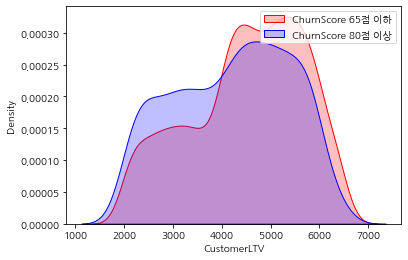

```python
sns.kdeplot(df_C0['CustomerLTV'], shade=True, label='ChurnScore 65점 이하',color='r')
sns.kdeplot(df_C80['CustomerLTV'], shade=True,label='ChurnScore 80점 이상',color='b')
plt.legend()
plt.show()
```

#### CutstomerLTV가 2000-4000구간에서는 df_C80이 가장 높은 값을 가지고, 4000-6000구간에서는 df_C0가 가장 높은 값을 가집니다.

#### => ChurnScore가 낮을수록 CustomerLTV가 높은 값을 가지며, ChurnScore가 높을수록 CustomerLTV가 낮은 값을 가집니다.

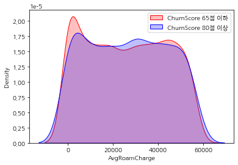

```python
sns.kdeplot(df_C0['AvgRoamCharge'], shade=True, label='ChurnScore 65점 이하',color='r')
sns.kdeplot(df_C80['AvgRoamCharge'], shade=True,label='ChurnScore 80점 이상',color='b')
plt.legend()
plt.show()
```

## 2.AvgCharge

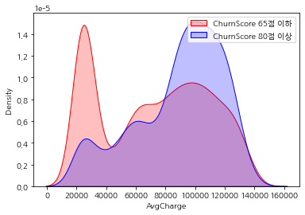

```python
sns.kdeplot(df_C0['AvgCharge'], shade=True, label='ChurnScore 65점 이하',color='r')
sns.kdeplot(df_C80['AvgCharge'], shade=True,label='ChurnScore 80점 이상',color='b')
plt.legend()
plt.show()
```

#### AvgCharge가 100000-150000구간에서는 df_C80이 가장 높은 값을 가지고, 0-50000구간에서는 df_C0가 가장 높은 값을 가집니다.

#### => ChurnScore가 낮을수록 AvgCharge가 낮은 값을 가지며, ChurnScore가 높을수록 AvgCharge가 높은 값을 가집니다.

## 3.AvgDownloadGB

[figure not shown]

```python
sns.kdeplot(df_C0['noDependents'], shade=True, label='ChurnScore 65점 미만',color='r')
sns.kdeplot(df_C80['noDependents'], shade=True,label='ChurnScore 65점 이상 80점 이하',color='b')
plt.legend()
plt.show()
```

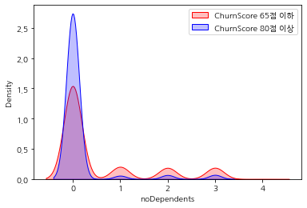

```python
sns.kdeplot(df_C0['noDependents'], shade=True, label='ChurnScore 65점 이하',color='r')
sns.kdeplot(df_C80['noDependents'], shade=True,label='ChurnScore 80점 이상',color='b')
plt.legend()
plt.show()
```

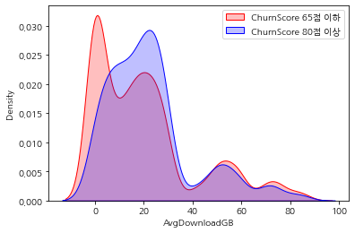

```python
sns.kdeplot(df_C0['AvgDownloadGB'], shade=True, label='ChurnScore 65점 이하',color='r')
sns.kdeplot(df_C80['AvgDownloadGB'], shade=True,label='ChurnScore 80점 이상',color='b')
plt.legend()
plt.show()
```

#### AvgDownloadGB가 10-30구간에서는 df_C80이 가장 높은 값을 가지고, 0-10구간에서는 df_C0가 가장 높은 값을 가집니다.

#### => ChurnScore가 낮을수록 AvgDownloadGB가 낮은 값을 가지며, ChurnScore가 높을수록 AvgDownloadGB가 높은 값을 가집니다.

#### **30이후의 값 해석??

## 4.noService

```python
df_C0['noService'].value_counts().sum()
```

```
3780
```

```python
X1 = [0,1,2,3]
```

```python
Y1 = [1597/3780,898/3780,809/3780,476/3780]
```

```python
df_C80['noService'].value_counts().sum()
```

```
1100
```

```python
X2 = [0.25,1.25,2.25,3.25]
```

```python
Y2 = [564/1100,349/1100,141/1100,46/1100]
```

[figure not shown]

```python
plt.bar(X1,Y1,color='b',width=0.25,label='이탈점수 65점 이하',alpha=0.5)
plt.bar(X2,Y2,color='r',width=0.25,label='이탈점수 80점 이하',alpha=0.5)
plt.xlabel('noService')
plt.legend()
```

#### noService가 0-1구간에서는 df_C80이 가장 높은 값을 가지고, 2-3구간에서는 df_C0가 가장 높은 값을 가집니다.

#### => ChurnScore가 낮을수록 Service를 많이 이용하며, ChurnScore가 높을수록 Service를 많이 이용하지 않습니다.

## 5.Married

```python
df_C0['Married'].value_counts()
```

```
No     2013
Yes    1767
Name: Married, dtype: int64
```

```python
X1 = [0,1]
Y1 = [2013/3780,1767/3780]
```

```python
df_C80['Married'].value_counts()
```

```
No     710
Yes    390
Name: Married, dtype: int64
```

```python
X2 = [0.25,1.25]
Y2 = [710/1100,390/1100]
```

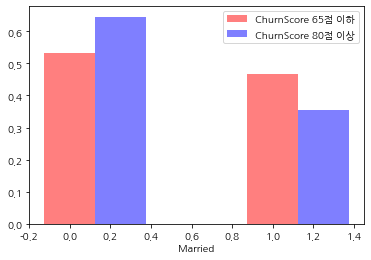

```python
plt.bar(X1,Y1,color='r',width=0.25,label='ChurnScore 65점 이하',alpha=0.5)
plt.bar(X2,Y2,color='b',width=0.25,label='ChurnScore 80점 이상',alpha=0.5)
plt.xlabel('Married')
plt.legend()
```

#### 미혼인 경우 churnscore가 높은 집단의 사람들이 많다.

#### 기혼의 경우 churnscore가 낮은 집단의 사람들이 많다.

#### 미혼을 위한 마케팅을 마련하여서 churnscore가 높은 집단을 타겟으로 마케팅을 실시 할 예정

### 6.noRefferals

```python
df_C0['noReferrals'].value_counts()
```

```
0     1867
1      427
5      181
7      177
3      171
9      171
4      170
6      158
10     156
8      155
2      145
11       2
Name: noReferrals, dtype: int64
```

```python
X1 = [0,1,2,3,4,5,6,7,8,9,10,11]
Y1 = [1867/3780,427/3780,145/3780,171/3780,170/3780,181/3780,158/3780,177/3780,155/3780,171/3780,156/3780,2/3780]
```

```python
df_C80['noReferrals'].value_counts()
```

```
0     701
1     303
3      24
2      18
5      14
4      10
8       9
6       6
10      6
7       5
9       4
Name: noReferrals, dtype: int64
```

```python
X2 = [0.25,1.25,2.25,3.25,4.25,5.25,6.25,7.25,8.25,9.25,10.25]
Y2 = [701/1100,303/1100,18/1100,24/1100,10/1100,14/1100,6/1100,5/1100,9/1100,4/1100,6/1100]
```

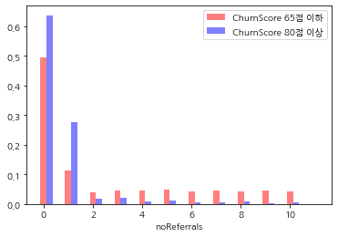

```python
plt.bar(X1,Y1,color='r',width=0.25,label='ChurnScore 65점 이하',alpha=0.5)
plt.bar(X2,Y2,color='b',width=0.25,label='ChurnScore 80점 이상',alpha=0.5)
plt.xlabel('noReferrals')
plt.legend()
```

#### 이탈률이 높은 집단의 경우 0,1의 추천이 많았다. 이 지표를 통해 고객 충성도를 파악 할 수 있으며, 사람들의 추천수를 높일 수 있는 방안을 마련하여 고객 충성도 및 이탈률 감소를 얻는 것이 목표이다. 추천인 이벤트 등을 통한 추천이벤트로 기존고객을 통한 신규고객유입 및 기존고객 유지방안이 최선임

### 7. TotalExtraDataCharge

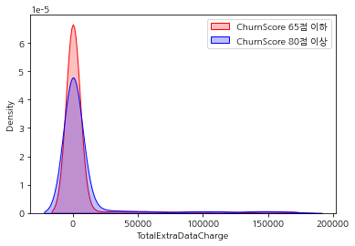

```python
sns.kdeplot(df_C0['TotalExtraDataCharge'], shade=True, label='ChurnScore 65점 이하',color='r')
sns.kdeplot(df_C80['TotalExtraDataCharge'], shade=True,label='ChurnScore 80점 이상',color='b')
plt.legend()
plt.show()
```

#### TotalExtraDataCharge에 대한 군집의 특징은 잘 나타나지않아보인다.

### 8.TenureMonths

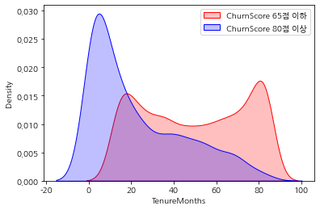

```python
sns.kdeplot(df_C0['TenureMonths'], shade=True, label='ChurnScore 65점 이하',color='r')
sns.kdeplot(df_C80['TenureMonths'], shade=True,label='ChurnScore 80점 이상',color='b')
plt.legend()
plt.show()
```

#### churnscore 군집에 따른 tenuremonths의 차이는 많이 나는 것으로 보인다. churnscore가 높은 집단의 tenuremonths는 0,20의 범위일때 가장 크게 나타난다. 안정적인 집단의 경우 60,100의 범위일 때 가장 차이가 크게 나타난다. 이러한 분포를 통해 tenuremonths와 churnscore가 높은 상관관계를 가질 것으로 예상. tenuremonths를 올릴 방안 구축을 위해 tenuremonths 분석을 따로 실시

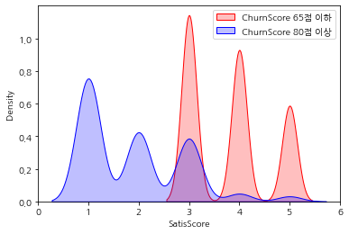

```python
sns.kdeplot(df_C0['SatisScore'], shade=True, label='ChurnScore 65점 이하',color='r')
sns.kdeplot(df_C80['SatisScore'], shade=True,label='ChurnScore 80점 이상',color='b')
plt.legend()
plt.show()
```

## 9.noDependents

```python
df_C0['noDependents'].value_counts()
```

```
0    2750
1     363
3     334
2     332
4       1
Name: noDependents, dtype: int64
```

# tenuremonths 집단 비교

```python
df_t0=df
```

```python
for i in range(len(df_t0)):
    if df_t0['TenureMonths'][i] <24 :
        continue
    else:
        df_t0=df_t0.drop([i],axis=0)
```

```python
df_t60=df
```

```python
for i in range(len(df_t60)):
    if df_t60['TenureMonths'][i] >60 :
        continue
    else:
        df_t60=df_t60.drop([i],axis=0)
```

```python
df_tmid=df
```

```python
for i in range(len(df_tmid)):
    if df_tmid['TenureMonths'][i] <=60 and  df_tmid['TenureMonths'][i] >=24 :
        continue
    else:
        df_tmid=df_tmid.drop([i],axis=0)
```

## 1.customerLTV

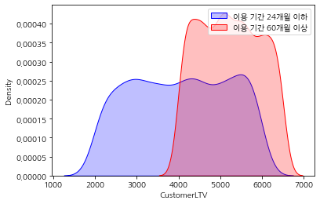

```python
sns.kdeplot(df_t0['CustomerLTV'], shade=True, label='이용 기간 24개월 이하',color='b')
sns.kdeplot(df_t60['CustomerLTV'], shade=True,label='이용 기간 60개월 이상',color='r')
plt.legend()
plt.show()
```

## 2.noRefferals

```python
df_t0['noReferrals'].value_counts()
```

```
0     1633
1      308
3       41
2       33
9       31
5       30
8       29
4       27
7       24
10      22
6       22
Name: noReferrals, dtype: int64
```

```python
X1 = [0,1,2,3,4,5,6,7,8,9,10]
Y1 = [1633/2200,308/2200,33/2200,41/2200,27/2200,30/2200,22/2200,24/2200,29/2200,31/2200,22/2200]
```

```python
df_t60['noReferrals'].value_counts()
```

```
0     683
1     341
5     141
9     135
7     133
4     124
3     118
2     118
10    116
8     108
6      99
11      1
Name: noReferrals, dtype: int64
```

```python
X2 = [0.25,1.25,2.25,3.25,4.25,5.25,6.25,7.25,8.25,9.25,10.25,11.25]
Y2 = [683/2117,341/2117,118/2117,118/2117,124/2117,141/2117,99/2117,133/2117,108/2117,135/2117,116/2117,1/2117]
```

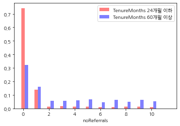

```python
plt.bar(X1,Y1,color='r',width=0.25,label='TenureMonths 24개월 이하',alpha=0.5)
plt.bar(X2,Y2,color='b',width=0.25,label='TenureMonths 60개월 이상',alpha=0.5)
plt.xlabel('noReferrals')
plt.legend()
```

## 3.AvgDownloadGB

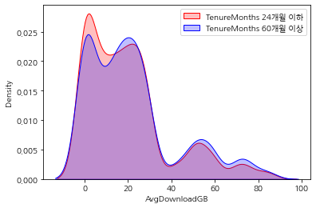

```python
sns.kdeplot(df_t0['AvgDownloadGB'], shade=True, label='TenureMonths 24개월 이하',color='r')
sns.kdeplot(df_t60['AvgDownloadGB'], shade=True,label='TenureMonths 60개월 이상',color='b')
plt.legend()
plt.show()
```

## 4.TotalExtraDataCharge

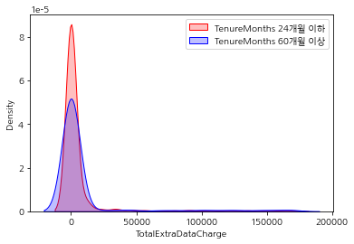

```python
sns.kdeplot(df_t0['TotalExtraDataCharge'], shade=True, label='TenureMonths 24개월 이하',color='r')
sns.kdeplot(df_t60['TotalExtraDataCharge'], shade=True,label='TenureMonths 60개월 이상',color='b')
plt.legend()
plt.show()
```

## 5.AvgRoamCharge

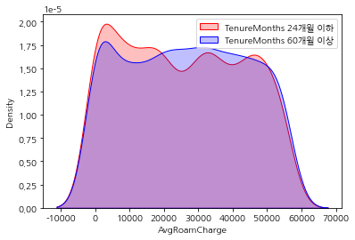

```python
sns.kdeplot(df_t0['AvgRoamCharge'], shade=True, label='TenureMonths 24개월 이하',color='r')
sns.kdeplot(df_t60['AvgRoamCharge'], shade=True,label='TenureMonths 60개월 이상',color='b')
plt.legend()
plt.show()
```

## 6.AvgCharge

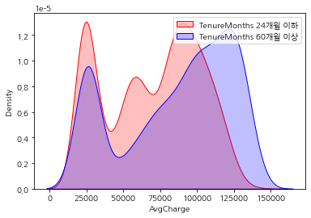

```python
sns.kdeplot(df_t0['AvgCharge'], shade=True, label='TenureMonths 24개월 이하',color='r')
sns.kdeplot(df_t60['AvgCharge'], shade=True,label='TenureMonths 60개월 이상',color='b')
plt.legend()
plt.show()
```

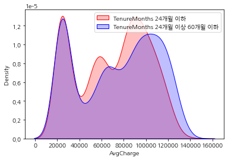

```python
sns.kdeplot(df_t0['AvgCharge'], shade=True, label='TenureMonths 24개월 이하',color='r')
sns.kdeplot(df_tmid['AvgCharge'], shade=True,label='TenureMonths 24개월 이상 60개월 이하',color='b')
plt.legend()
plt.show()
```

## 7.noService

```python
df_t0['noService'].value_counts()
```

```
0    1435
1     572
2     166
3      27
Name: noService, dtype: int64
```

```python
X1 = [0,1,2,3]
Y1 = [1435/2200,572/2200,166/2200,27/2200]
```

```python
df_t60['noService'].value_counts()
```

```
2    653
0    547
3    500
1    417
Name: noService, dtype: int64
```

```python
X2 = [0.25,1.25,2.25,3.25]
Y2 = [547/2117,417/2117,653/2117,500/2117]
```

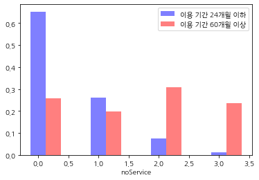

```python
plt.bar(X1,Y1,color='b',width=0.25,label='이용 기간 24개월 이하',alpha=0.5)
plt.bar(X2,Y2,color='r',width=0.25,label='이용 기간 60개월 이상',alpha=0.5)
plt.xlabel('noService')
plt.legend()
```

## age

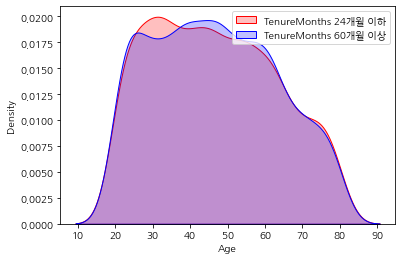

```python
sns.kdeplot(df_t0['Age'], shade=True, label='TenureMonths 24개월 이하',color='r')
sns.kdeplot(df_t60['Age'], shade=True,label='TenureMonths 60개월 이상',color='b')
plt.legend()
plt.show()
```

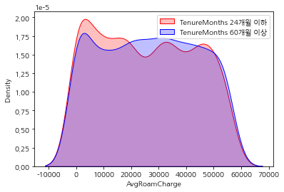

```python
sns.kdeplot(df_t0['AvgRoamCharge'], shade=True, label='TenureMonths 24개월 이하',color='r')
sns.kdeplot(df_t60['AvgRoamCharge'], shade=True,label='TenureMonths 60개월 이상',color='b')
plt.legend()
plt.show()
```

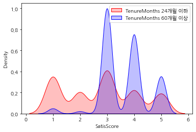

```python
sns.kdeplot(df_t0['SatisScore'], shade=True, label='TenureMonths 24개월 이하',color='r')
sns.kdeplot(df_t60['SatisScore'], shade=True,label='TenureMonths 60개월 이상',color='b')
plt.legend()
plt.show()
```

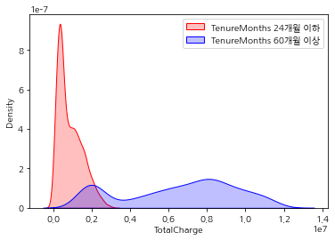

```python
sns.kdeplot(df_t0['TotalCharge'], shade=True, label='TenureMonths 24개월 이하',color='r')
sns.kdeplot(df_t60['TotalCharge'], shade=True,label='TenureMonths 60개월 이상',color='b')
plt.legend()
plt.show()
```

# AvgCharge

```python
df_avg0=df
```

```python
for i in range(len(df_avg0)):
    if df_avg0['AvgCharge'][i] <=80000 :
        continue
    else:
        df_avg0=df_avg0.drop([i],axis=0)
```

```python
df_avg80000=df
```

```python
for i in range(len(df_avg80000)):
    if df_avg80000['AvgCharge'][i] >=80000 :
        continue
    else:
        df_avg80000=df_avg80000.drop([i],axis=0)
```

## LTV

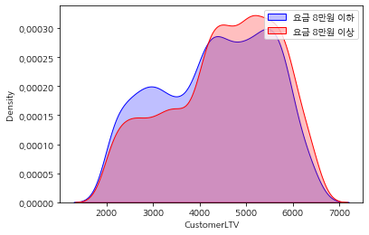

```python
sns.kdeplot(df_avg0['CustomerLTV'], shade=True, label='요금 8만원 이하',color='b')
sns.kdeplot(df_avg80000['CustomerLTV'], shade=True,label='요금 8만원 이상',color='r')
plt.legend()
plt.show()
```

## noService

```python
df_avg0['noService'].value_counts()
```

```
0    2036
1     605
2     429
3     162
Name: noService, dtype: int64
```

```python
X1 = [0,1,2,3]
Y1 = [2036/3232,605/3232,429/3232,162/3232]
```

```python
df_avg80000['noService'].value_counts()
```

```
1    1177
0    1056
2     874
3     525
Name: noService, dtype: int64
```

```python
X2 = [0.25,1.25,2.25,3.25]
Y2 = [1056/3632,1177/3632,874/3632,525/3632]
```

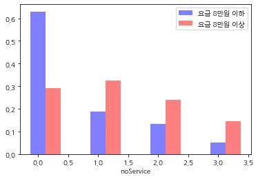

```python
plt.bar(X1,Y1,color='b',width=0.25,label='요금 8만원 이하',alpha=0.5)
plt.bar(X2,Y2,color='r',width=0.25,label='요금 8만원 이상',alpha=0.5)
plt.xlabel('noService')
plt.legend()
```

## noReferrals

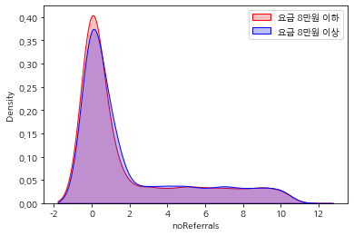

```python
sns.kdeplot(df_avg0['noReferrals'], shade=True, label='요금 8만원 이하',color='r')
sns.kdeplot(df_avg80000['noReferrals'], shade=True,label='요금 8만원 이상',color='b')
plt.legend()
plt.show()
```

## Age

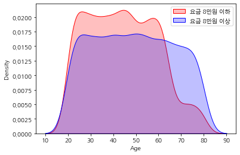

```python
sns.kdeplot(df_avg0['Age'], shade=True, label='요금 8만원 이하',color='r')
sns.kdeplot(df_avg80000['Age'], shade=True,label='요금 8만원 이상',color='b')
plt.legend()
plt.show()
```

# LTV와 연관되어있는 TenureMonths, AvgCharge와 noService 상관관계 분석

```python
from scipy import stats
```

```python
stats.pearsonr(df['noService'],df['TenureMonths'])
```

```
(0.4473185128921011, 0.0)
```

```python
stats.pearsonr(df['noService'],df['AvgCharge'])
```

```
(0.4921469801904303, 0.0)
```

```python
dff=df[['AvgCharge','TenureMonths','noService']]
```

```python
corr=dff.corr(method='pearson')
```

```python
corr
```

|  | AvgCharge | TenureMonths | noService |
| --- | --- | --- | --- |
| AvgCharge | 1.000000 | 0.185090 | 0.492147 |
| TenureMonths | 0.185090 | 1.000000 | 0.447319 |
| noService | 0.492147 | 0.447319 | 1.000000 |

```python
import scipy.stats as stats
stats.pointbiserialr(df['noService'],df['AvgCharge'])
```

```
PointbiserialrResult(correlation=0.4921469801904303, pvalue=0.0)
```

```python
stats.pointbiserialr(df['noService'],df['TenureMonths'])
```

```
PointbiserialrResult(correlation=0.4473185128921011, pvalue=0.0)
```

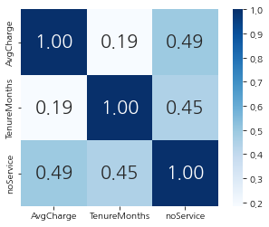

```python
df_heatmap = sns.heatmap(corr, cbar = True, annot = True, annot_kws={'size' : 20},
                         fmt = '.2f', square = True, cmap = 'Blues')
```

# noDependents

```python
df_node=df
```

```python
for i in range(len(df_node)):
    if df_node['noDependents'][i] == 0:
        continue
    else:
        df_node=df_node.drop([i],axis=0)
```

```python
df_node
```

|  | Unnamed: 0 | CustomerId | Gender | Age | AgeGroup | Married | Dependents | noDependents | Referrals | noReferrals | ... | CustomerLTV | SatisScore | TotalExtraDataCharge | AvgRoamCharge | TotalRoamCharge | TotalCharge | AvgCharge | TotalRevenue | TenureMonths | noService |
| --- | --- | --- | --- | --- | --- | --- | --- | --- | --- | --- | --- | --- | --- | --- | --- | --- | --- | --- | --- | --- | --- |
| 0 | 0 | C-10001 | 여성 | 37 | 30대 | Yes | No | 0 | Yes | 2 | ... | 2205 | 3 | 0 | 47910 | 431100 | 1755400 | 83590 | 2186500 | 21 | 2 |
| 1 | 1 | C-10002 | 남성 | 46 | 40대 | No | No | 0 | No | 0 | ... | 5414 | 5 | 11300 | 12090 | 108710 | 1447500 | 68928 | 1567510 | 21 | 0 |
| 2 | 2 | C-10003 | 남성 | 50 | 50대 | No | No | 0 | No | 0 | ... | 4479 | 1 | 0 | 38080 | 152100 | 490900 | 98180 | 643000 | 4 | 0 |
| 3 | 3 | C-10004 | 남성 | 78 | 70대 | Yes | No | 0 | Yes | 1 | ... | 3714 | 1 | 0 | 31410 | 408720 | 1578400 | 112742 | 1987120 | 13 | 1 |
| 4 | 4 | C-10005 | 여성 | 75 | 70대 | Yes | No | 0 | Yes | 3 | ... | 3464 | 1 | 0 | 8360 | 24970 | 378000 | 94500 | 402970 | 3 | 1 |
| ... | ... | ... | ... | ... | ... | ... | ... | ... | ... | ... | ... | ... | ... | ... | ... | ... | ... | ... | ... | ... | ... |
| 6858 | 6858 | C-17039 | 여성 | 20 | 20대 | No | No | 0 | No | 0 | ... | 3161 | 4 | 0 | 52770 | 685680 | 1610700 | 64428 | 2296380 | 25 | 2 |
| 6859 | 6859 | C-17040 | 남성 | 40 | 40대 | Yes | No | 0 | Yes | 1 | ... | 5248 | 1 | 0 | 18310 | 402730 | 2343500 | 101891 | 2746230 | 22 | 0 |
| 6860 | 6860 | C-17041 | 남성 | 22 | 20대 | No | No | 0 | No | 0 | ... | 5870 | 5 | 0 | 21020 | 42040 | 792400 | 56600 | 834440 | 14 | 1 |
| 6861 | 6861 | C-17042 | 남성 | 21 | 20대 | No | No | 0 | Yes | 5 | ... | 4792 | 3 | 0 | 2370 | 160460 | 6328500 | 80107 | 6488960 | 79 | 2 |
| 6862 | 6862 | C-17043 | 남성 | 36 | 30대 | Yes | No | 0 | Yes | 1 | ... | 5639 | 3 | 0 | 0 | 0 | 5196100 | 69281 | 5196100 | 75 | 2 |

5410 rows × 34 columns

```python
df_node['ChurnLabel'].value_counts()
```

```
No     3799
Yes    1611
Name: ChurnLabel, dtype: int64
```

```python
1611/5410
```

```
0.2977818853974122
```

```python
df_node1=df
```

```python
for i in range(len(df_node1)):
    if df_node1['noDependents'][i] == 1:
        continue
    else:
        df_node1=df_node1.drop([i],axis=0)
```

```python
df_node1['ChurnLabel'].value_counts()
```

```
No     494
Yes     38
Name: ChurnLabel, dtype: int64
```

```python
38/532
```

```
0.07142857142857142
```

```python
df_node['ChurnScore'].mean()
```

```
59.874306839186694
```

```python
df_node1['ChurnScore'].mean()
```

```
52.32142857142857
```

# noReferrals

```python
df_nore=df
```

```python
for i in range(len(df_nore)):
    if df_nore['noReferrals'][i] == 0:
        continue
    else:
        df_nore=df_nore.drop([i],axis=0)
```

```python
df_nore['ChurnLabel'].value_counts()
```

```
No     2574
Yes    1108
Name: ChurnLabel, dtype: int64
```

```python
1108/3682
```

```
0.3009234111895709
```

```python
df_nore1=df
```

```python
for i in range(len(df_nore1)):
    if df_nore1['noReferrals'][i] != 0:
        continue
    else:
        df_nore1=df_nore1.drop([i],axis=0)
```

```python
df_nore1['ChurnLabel'].value_counts()
```

```
No     2587
Yes     594
Name: ChurnLabel, dtype: int64
```

```python
594/3181
```

```
0.18673373153096512
```

# noService

```python
df_nose=df
```

```python
for i in range(len(df_nose)):
    if df_nose['noService'][i] == 0:
        continue
    else:
        df_nose=df_nose.drop([i],axis=0)
```

```python
df_nose['ChurnLabel'].value_counts()
```

```
No     2194
Yes     897
Name: ChurnLabel, dtype: int64
```

```python
897/(2194+897)
```

```
0.2901973471368489
```

```python
df_nose1=df
```

```python
for i in range(len(df_nose1)):
    if df_nose1['noService'][i] != 0:
        continue
    else:
        df_nose1=df_nose1.drop([i],axis=0)
```

```python
df_nose1['ChurnLabel'].value_counts()
```

```
No     2967
Yes     805
Name: ChurnLabel, dtype: int64
```

```python
805/(2967+805)
```

```
0.21341463414634146
```